# project (2)

**Project:Covid Data Analysis**

*The source of the data is from JohnsHopkins University. There are three datasets first is for the confirmed covid cases which consists of 266 rows and 248 columns, second data is recovered covid cases which consist of 253 rows and 248 columns, and last dataset is death covid cases consist of 266 rows and 248 columns*

*The columns are*

*Province/State,Country/Region,Lat,Long,and the rest of the columns containing the dates.*

**Importing necessary modules**

```python
import pandas as pd
import matplotlib.pyplot as plt
from matplotlib import style
%matplotlib inline
import plotly
import plotly.express as px
import plotly.graph_objects as go
import seaborn as sns
```

**Reading the datasets**

```python
Confirmed=pd.read_csv('/content/time_series_covid19_confirmed_global.csv')
Confirmed
```

|  | Province/State | Country/Region | Lat | Long | 1/22/20 | 1/23/20 | 1/24/20 | 1/25/20 | 1/26/20 | 1/27/20 | ... | 9/12/20 | 9/13/20 | 9/14/20 | 9/15/20 | 9/16/20 | 9/17/20 | 9/18/20 | 9/19/20 | 9/20/20 | 9/21/20 |
| --- | --- | --- | --- | --- | --- | --- | --- | --- | --- | --- | --- | --- | --- | --- | --- | --- | --- | --- | --- | --- | --- |
| 0 | NaN | Afghanistan | 33.939110 | 67.709953 | 0 | 0 | 0 | 0 | 0 | 0 | ... | 38641 | 38716 | 38772 | 38815 | 38855 | 38872 | 38883 | 38919 | 39044 | 39074 |
| 1 | NaN | Albania | 41.153300 | 20.168300 | 0 | 0 | 0 | 0 | 0 | 0 | ... | 11185 | 11353 | 11520 | 11672 | 11816 | 11948 | 12073 | 12226 | 12385 | 12535 |
| 2 | NaN | Algeria | 28.033900 | 1.659600 | 0 | 0 | 0 | 0 | 0 | 0 | ... | 48007 | 48254 | 48496 | 48734 | 48966 | 49194 | 49413 | 49623 | 49826 | 50023 |
| 3 | NaN | Andorra | 42.506300 | 1.521800 | 0 | 0 | 0 | 0 | 0 | 0 | ... | 1344 | 1344 | 1438 | 1438 | 1483 | 1483 | 1564 | 1564 | 1564 | 1681 |
| 4 | NaN | Angola | -11.202700 | 17.873900 | 0 | 0 | 0 | 0 | 0 | 0 | ... | 3335 | 3388 | 3439 | 3569 | 3675 | 3789 | 3848 | 3901 | 3991 | 4117 |
| ... | ... | ... | ... | ... | ... | ... | ... | ... | ... | ... | ... | ... | ... | ... | ... | ... | ... | ... | ... | ... | ... |
| 261 | NaN | West Bank and Gaza | 31.952200 | 35.233200 | 0 | 0 | 0 | 0 | 0 | 0 | ... | 29906 | 30574 | 31362 | 32250 | 33006 | 33843 | 34401 | 35003 | 35686 | 36151 |
| 262 | NaN | Western Sahara | 24.215500 | -12.885800 | 0 | 0 | 0 | 0 | 0 | 0 | ... | 10 | 10 | 10 | 10 | 10 | 10 | 10 | 10 | 10 | 10 |
| 263 | NaN | Yemen | 15.552727 | 48.516388 | 0 | 0 | 0 | 0 | 0 | 0 | ... | 2009 | 2011 | 2013 | 2016 | 2019 | 2022 | 2024 | 2026 | 2026 | 2028 |
| 264 | NaN | Zambia | -13.133897 | 27.849332 | 0 | 0 | 0 | 0 | 0 | 0 | ... | 13466 | 13539 | 13720 | 13819 | 13887 | 13928 | 14022 | 14070 | 14131 | 14175 |
| 265 | NaN | Zimbabwe | -19.015438 | 29.154857 | 0 | 0 | 0 | 0 | 0 | 0 | ... | 7508 | 7526 | 7531 | 7576 | 7598 | 7633 | 7647 | 7672 | 7683 | 7683 |

266 rows × 248 columns

```python
Recovered=pd.read_csv('/content/time_series_covid19_recovered_global.csv')
Recovered
```

|  | Province/State | Country/Region | Lat | Long | 1/22/20 | 1/23/20 | 1/24/20 | 1/25/20 | 1/26/20 | 1/27/20 | ... | 9/12/20 | 9/13/20 | 9/14/20 | 9/15/20 | 9/16/20 | 9/17/20 | 9/18/20 | 9/19/20 | 9/20/20 | 9/21/20 |
| --- | --- | --- | --- | --- | --- | --- | --- | --- | --- | --- | --- | --- | --- | --- | --- | --- | --- | --- | --- | --- | --- |
| 0 | NaN | Afghanistan | 33.939110 | 67.709953 | 0 | 0 | 0 | 0 | 0 | 0 | ... | 31234 | 31638 | 32073 | 32098 | 32503 | 32505 | 32576 | 32576 | 32576 | 32576 |
| 1 | NaN | Albania | 41.153300 | 20.168300 | 0 | 0 | 0 | 0 | 0 | 0 | ... | 6494 | 6569 | 6615 | 6668 | 6733 | 6788 | 6831 | 6888 | 6940 | 6995 |
| 2 | NaN | Algeria | 28.033900 | 1.659600 | 0 | 0 | 0 | 0 | 0 | 0 | ... | 33875 | 34037 | 34204 | 34385 | 34517 | 34675 | 34818 | 34923 | 35047 | 35180 |
| 3 | NaN | Andorra | 42.506300 | 1.521800 | 0 | 0 | 0 | 0 | 0 | 0 | ... | 943 | 943 | 945 | 945 | 1054 | 1054 | 1164 | 1164 | 1164 | 1199 |
| 4 | NaN | Angola | -11.202700 | 17.873900 | 0 | 0 | 0 | 0 | 0 | 0 | ... | 1289 | 1301 | 1324 | 1332 | 1401 | 1405 | 1443 | 1445 | 1445 | 1449 |
| ... | ... | ... | ... | ... | ... | ... | ... | ... | ... | ... | ... | ... | ... | ... | ... | ... | ... | ... | ... | ... | ... |
| 248 | NaN | West Bank and Gaza | 31.952200 | 35.233200 | 0 | 0 | 0 | 0 | 0 | 0 | ... | 19979 | 20082 | 21406 | 21804 | 22209 | 23060 | 23333 | 23446 | 23700 | 24428 |
| 249 | NaN | Western Sahara | 24.215500 | -12.885800 | 0 | 0 | 0 | 0 | 0 | 0 | ... | 8 | 8 | 8 | 8 | 8 | 8 | 8 | 8 | 8 | 8 |
| 250 | NaN | Yemen | 15.552727 | 48.516388 | 0 | 0 | 0 | 0 | 0 | 0 | ... | 1211 | 1212 | 1215 | 1219 | 1221 | 1221 | 1221 | 1221 | 1227 | 1235 |
| 251 | NaN | Zambia | -13.133897 | 27.849332 | 0 | 0 | 0 | 0 | 0 | 0 | ... | 12007 | 12260 | 12380 | 12590 | 12869 | 13029 | 13207 | 13365 | 13365 | 13629 |
| 252 | NaN | Zimbabwe | -19.015438 | 29.154857 | 0 | 0 | 0 | 0 | 0 | 0 | ... | 5675 | 5678 | 5690 | 5783 | 5823 | 5841 | 5883 | 5914 | 5924 | 5924 |

253 rows × 248 columns

```python
Death=pd.read_csv('/content/time_series_covid19_deaths_global.csv')
Death
```

|  | Province/State | Country/Region | Lat | Long | 1/22/20 | 1/23/20 | 1/24/20 | 1/25/20 | 1/26/20 | 1/27/20 | ... | 9/12/20 | 9/13/20 | 9/14/20 | 9/15/20 | 9/16/20 | 9/17/20 | 9/18/20 | 9/19/20 | 9/20/20 | 9/21/20 |
| --- | --- | --- | --- | --- | --- | --- | --- | --- | --- | --- | --- | --- | --- | --- | --- | --- | --- | --- | --- | --- | --- |
| 0 | NaN | Afghanistan | 33.939110 | 67.709953 | 0 | 0 | 0 | 0 | 0 | 0 | ... | 1420 | 1420 | 1425 | 1426 | 1436 | 1436 | 1437 | 1437 | 1441 | 1444 |
| 1 | NaN | Albania | 41.153300 | 20.168300 | 0 | 0 | 0 | 0 | 0 | 0 | ... | 330 | 334 | 338 | 340 | 343 | 347 | 353 | 358 | 362 | 364 |
| 2 | NaN | Algeria | 28.033900 | 1.659600 | 0 | 0 | 0 | 0 | 0 | 0 | ... | 1605 | 1612 | 1620 | 1632 | 1645 | 1654 | 1659 | 1665 | 1672 | 1679 |
| 3 | NaN | Andorra | 42.506300 | 1.521800 | 0 | 0 | 0 | 0 | 0 | 0 | ... | 53 | 53 | 53 | 53 | 53 | 53 | 53 | 53 | 53 | 53 |
| 4 | NaN | Angola | -11.202700 | 17.873900 | 0 | 0 | 0 | 0 | 0 | 0 | ... | 132 | 134 | 136 | 139 | 143 | 144 | 147 | 147 | 152 | 154 |
| ... | ... | ... | ... | ... | ... | ... | ... | ... | ... | ... | ... | ... | ... | ... | ... | ... | ... | ... | ... | ... | ... |
| 261 | NaN | West Bank and Gaza | 31.952200 | 35.233200 | 0 | 0 | 0 | 0 | 0 | 0 | ... | 210 | 221 | 226 | 229 | 243 | 244 | 250 | 253 | 262 | 265 |
| 262 | NaN | Western Sahara | 24.215500 | -12.885800 | 0 | 0 | 0 | 0 | 0 | 0 | ... | 1 | 1 | 1 | 1 | 1 | 1 | 1 | 1 | 1 | 1 |
| 263 | NaN | Yemen | 15.552727 | 48.516388 | 0 | 0 | 0 | 0 | 0 | 0 | ... | 582 | 583 | 583 | 583 | 583 | 585 | 585 | 585 | 586 | 586 |
| 264 | NaN | Zambia | -13.133897 | 27.849332 | 0 | 0 | 0 | 0 | 0 | 0 | ... | 312 | 312 | 320 | 324 | 326 | 326 | 329 | 330 | 330 | 331 |
| 265 | NaN | Zimbabwe | -19.015438 | 29.154857 | 0 | 0 | 0 | 0 | 0 | 0 | ... | 224 | 224 | 224 | 224 | 224 | 224 | 224 | 225 | 225 | 225 |

266 rows × 248 columns

**Renaming the columns Province/Country into Province and Country/Region into Country**

```python
def Import_Covid19data(filepath):
    data = filepath
    data = pd.read_csv(data)
    data.rename(columns={'Province/State':'Province','Country/Region':'Country'},inplace = True)
    return data
```

**Transforming given data by adding a column for dates**

```python
def transform_Covid19data(data):
    data = pd.melt(
    frame = data,
    id_vars = ['Province','Country','Lat','Long','Status'],
    var_name = 'Date',
    value_name = 'Count'
    )
    return data
```

```python
ConfirmedCases=Import_Covid19data("/content/time_series_covid19_confirmed_global.csv")
ConfirmedCases
```

|  | Province | Country | Lat | Long | 1/22/20 | 1/23/20 | 1/24/20 | 1/25/20 | 1/26/20 | 1/27/20 | ... | 9/12/20 | 9/13/20 | 9/14/20 | 9/15/20 | 9/16/20 | 9/17/20 | 9/18/20 | 9/19/20 | 9/20/20 | 9/21/20 |
| --- | --- | --- | --- | --- | --- | --- | --- | --- | --- | --- | --- | --- | --- | --- | --- | --- | --- | --- | --- | --- | --- |
| 0 | NaN | Afghanistan | 33.939110 | 67.709953 | 0 | 0 | 0 | 0 | 0 | 0 | ... | 38641 | 38716 | 38772 | 38815 | 38855 | 38872 | 38883 | 38919 | 39044 | 39074 |
| 1 | NaN | Albania | 41.153300 | 20.168300 | 0 | 0 | 0 | 0 | 0 | 0 | ... | 11185 | 11353 | 11520 | 11672 | 11816 | 11948 | 12073 | 12226 | 12385 | 12535 |
| 2 | NaN | Algeria | 28.033900 | 1.659600 | 0 | 0 | 0 | 0 | 0 | 0 | ... | 48007 | 48254 | 48496 | 48734 | 48966 | 49194 | 49413 | 49623 | 49826 | 50023 |
| 3 | NaN | Andorra | 42.506300 | 1.521800 | 0 | 0 | 0 | 0 | 0 | 0 | ... | 1344 | 1344 | 1438 | 1438 | 1483 | 1483 | 1564 | 1564 | 1564 | 1681 |
| 4 | NaN | Angola | -11.202700 | 17.873900 | 0 | 0 | 0 | 0 | 0 | 0 | ... | 3335 | 3388 | 3439 | 3569 | 3675 | 3789 | 3848 | 3901 | 3991 | 4117 |
| ... | ... | ... | ... | ... | ... | ... | ... | ... | ... | ... | ... | ... | ... | ... | ... | ... | ... | ... | ... | ... | ... |
| 261 | NaN | West Bank and Gaza | 31.952200 | 35.233200 | 0 | 0 | 0 | 0 | 0 | 0 | ... | 29906 | 30574 | 31362 | 32250 | 33006 | 33843 | 34401 | 35003 | 35686 | 36151 |
| 262 | NaN | Western Sahara | 24.215500 | -12.885800 | 0 | 0 | 0 | 0 | 0 | 0 | ... | 10 | 10 | 10 | 10 | 10 | 10 | 10 | 10 | 10 | 10 |
| 263 | NaN | Yemen | 15.552727 | 48.516388 | 0 | 0 | 0 | 0 | 0 | 0 | ... | 2009 | 2011 | 2013 | 2016 | 2019 | 2022 | 2024 | 2026 | 2026 | 2028 |
| 264 | NaN | Zambia | -13.133897 | 27.849332 | 0 | 0 | 0 | 0 | 0 | 0 | ... | 13466 | 13539 | 13720 | 13819 | 13887 | 13928 | 14022 | 14070 | 14131 | 14175 |
| 265 | NaN | Zimbabwe | -19.015438 | 29.154857 | 0 | 0 | 0 | 0 | 0 | 0 | ... | 7508 | 7526 | 7531 | 7576 | 7598 | 7633 | 7647 | 7672 | 7683 | 7683 |

266 rows × 248 columns

*adding a column named Status and gives the value confirmed*

```python
ConfirmedCases['Status'] = 'Confirmed'
```

```python
ConfirmedCases = transform_Covid19data(ConfirmedCases)
```

```python
ConfirmedCases
```

|  | Province | Country | Lat | Long | Status | Date | Count |
| --- | --- | --- | --- | --- | --- | --- | --- |
| 0 | NaN | Afghanistan | 33.939110 | 67.709953 | Confirmed | 1/22/20 | 0 |
| 1 | NaN | Albania | 41.153300 | 20.168300 | Confirmed | 1/22/20 | 0 |
| 2 | NaN | Algeria | 28.033900 | 1.659600 | Confirmed | 1/22/20 | 0 |
| 3 | NaN | Andorra | 42.506300 | 1.521800 | Confirmed | 1/22/20 | 0 |
| 4 | NaN | Angola | -11.202700 | 17.873900 | Confirmed | 1/22/20 | 0 |
| ... | ... | ... | ... | ... | ... | ... | ... |
| 64899 | NaN | West Bank and Gaza | 31.952200 | 35.233200 | Confirmed | 9/21/20 | 36151 |
| 64900 | NaN | Western Sahara | 24.215500 | -12.885800 | Confirmed | 9/21/20 | 10 |
| 64901 | NaN | Yemen | 15.552727 | 48.516388 | Confirmed | 9/21/20 | 2028 |
| 64902 | NaN | Zambia | -13.133897 | 27.849332 | Confirmed | 9/21/20 | 14175 |
| 64903 | NaN | Zimbabwe | -19.015438 | 29.154857 | Confirmed | 9/21/20 | 7683 |

64904 rows × 7 columns

```python
RecoveredCases = Import_Covid19data("/content/time_series_covid19_recovered_global.csv")
RecoveredCases
```

|  | Province | Country | Lat | Long | 1/22/20 | 1/23/20 | 1/24/20 | 1/25/20 | 1/26/20 | 1/27/20 | ... | 9/12/20 | 9/13/20 | 9/14/20 | 9/15/20 | 9/16/20 | 9/17/20 | 9/18/20 | 9/19/20 | 9/20/20 | 9/21/20 |
| --- | --- | --- | --- | --- | --- | --- | --- | --- | --- | --- | --- | --- | --- | --- | --- | --- | --- | --- | --- | --- | --- |
| 0 | NaN | Afghanistan | 33.939110 | 67.709953 | 0 | 0 | 0 | 0 | 0 | 0 | ... | 31234 | 31638 | 32073 | 32098 | 32503 | 32505 | 32576 | 32576 | 32576 | 32576 |
| 1 | NaN | Albania | 41.153300 | 20.168300 | 0 | 0 | 0 | 0 | 0 | 0 | ... | 6494 | 6569 | 6615 | 6668 | 6733 | 6788 | 6831 | 6888 | 6940 | 6995 |
| 2 | NaN | Algeria | 28.033900 | 1.659600 | 0 | 0 | 0 | 0 | 0 | 0 | ... | 33875 | 34037 | 34204 | 34385 | 34517 | 34675 | 34818 | 34923 | 35047 | 35180 |
| 3 | NaN | Andorra | 42.506300 | 1.521800 | 0 | 0 | 0 | 0 | 0 | 0 | ... | 943 | 943 | 945 | 945 | 1054 | 1054 | 1164 | 1164 | 1164 | 1199 |
| 4 | NaN | Angola | -11.202700 | 17.873900 | 0 | 0 | 0 | 0 | 0 | 0 | ... | 1289 | 1301 | 1324 | 1332 | 1401 | 1405 | 1443 | 1445 | 1445 | 1449 |
| ... | ... | ... | ... | ... | ... | ... | ... | ... | ... | ... | ... | ... | ... | ... | ... | ... | ... | ... | ... | ... | ... |
| 248 | NaN | West Bank and Gaza | 31.952200 | 35.233200 | 0 | 0 | 0 | 0 | 0 | 0 | ... | 19979 | 20082 | 21406 | 21804 | 22209 | 23060 | 23333 | 23446 | 23700 | 24428 |
| 249 | NaN | Western Sahara | 24.215500 | -12.885800 | 0 | 0 | 0 | 0 | 0 | 0 | ... | 8 | 8 | 8 | 8 | 8 | 8 | 8 | 8 | 8 | 8 |
| 250 | NaN | Yemen | 15.552727 | 48.516388 | 0 | 0 | 0 | 0 | 0 | 0 | ... | 1211 | 1212 | 1215 | 1219 | 1221 | 1221 | 1221 | 1221 | 1227 | 1235 |
| 251 | NaN | Zambia | -13.133897 | 27.849332 | 0 | 0 | 0 | 0 | 0 | 0 | ... | 12007 | 12260 | 12380 | 12590 | 12869 | 13029 | 13207 | 13365 | 13365 | 13629 |
| 252 | NaN | Zimbabwe | -19.015438 | 29.154857 | 0 | 0 | 0 | 0 | 0 | 0 | ... | 5675 | 5678 | 5690 | 5783 | 5823 | 5841 | 5883 | 5914 | 5924 | 5924 |

253 rows × 248 columns

**adding a column named Status and gives the value Recovered**

```python
RecoveredCases['Status'] ='Recovered'
```

```python
RecoveredCases = transform_Covid19data(RecoveredCases)
```

```python
RecoveredCases
```

|  | Province | Country | Lat | Long | Status | Date | Count |
| --- | --- | --- | --- | --- | --- | --- | --- |
| 0 | NaN | Afghanistan | 33.939110 | 67.709953 | Recovered | 1/22/20 | 0 |
| 1 | NaN | Albania | 41.153300 | 20.168300 | Recovered | 1/22/20 | 0 |
| 2 | NaN | Algeria | 28.033900 | 1.659600 | Recovered | 1/22/20 | 0 |
| 3 | NaN | Andorra | 42.506300 | 1.521800 | Recovered | 1/22/20 | 0 |
| 4 | NaN | Angola | -11.202700 | 17.873900 | Recovered | 1/22/20 | 0 |
| ... | ... | ... | ... | ... | ... | ... | ... |
| 61727 | NaN | West Bank and Gaza | 31.952200 | 35.233200 | Recovered | 9/21/20 | 24428 |
| 61728 | NaN | Western Sahara | 24.215500 | -12.885800 | Recovered | 9/21/20 | 8 |
| 61729 | NaN | Yemen | 15.552727 | 48.516388 | Recovered | 9/21/20 | 1235 |
| 61730 | NaN | Zambia | -13.133897 | 27.849332 | Recovered | 9/21/20 | 13629 |
| 61731 | NaN | Zimbabwe | -19.015438 | 29.154857 | Recovered | 9/21/20 | 5924 |

61732 rows × 7 columns

```python
DeathCases = Import_Covid19data("/content/time_series_covid19_deaths_global.csv")
```

```python
DeathCases
```

|  | Province | Country | Lat | Long | 1/22/20 | 1/23/20 | 1/24/20 | 1/25/20 | 1/26/20 | 1/27/20 | ... | 9/12/20 | 9/13/20 | 9/14/20 | 9/15/20 | 9/16/20 | 9/17/20 | 9/18/20 | 9/19/20 | 9/20/20 | 9/21/20 |
| --- | --- | --- | --- | --- | --- | --- | --- | --- | --- | --- | --- | --- | --- | --- | --- | --- | --- | --- | --- | --- | --- |
| 0 | NaN | Afghanistan | 33.939110 | 67.709953 | 0 | 0 | 0 | 0 | 0 | 0 | ... | 1420 | 1420 | 1425 | 1426 | 1436 | 1436 | 1437 | 1437 | 1441 | 1444 |
| 1 | NaN | Albania | 41.153300 | 20.168300 | 0 | 0 | 0 | 0 | 0 | 0 | ... | 330 | 334 | 338 | 340 | 343 | 347 | 353 | 358 | 362 | 364 |
| 2 | NaN | Algeria | 28.033900 | 1.659600 | 0 | 0 | 0 | 0 | 0 | 0 | ... | 1605 | 1612 | 1620 | 1632 | 1645 | 1654 | 1659 | 1665 | 1672 | 1679 |
| 3 | NaN | Andorra | 42.506300 | 1.521800 | 0 | 0 | 0 | 0 | 0 | 0 | ... | 53 | 53 | 53 | 53 | 53 | 53 | 53 | 53 | 53 | 53 |
| 4 | NaN | Angola | -11.202700 | 17.873900 | 0 | 0 | 0 | 0 | 0 | 0 | ... | 132 | 134 | 136 | 139 | 143 | 144 | 147 | 147 | 152 | 154 |
| ... | ... | ... | ... | ... | ... | ... | ... | ... | ... | ... | ... | ... | ... | ... | ... | ... | ... | ... | ... | ... | ... |
| 261 | NaN | West Bank and Gaza | 31.952200 | 35.233200 | 0 | 0 | 0 | 0 | 0 | 0 | ... | 210 | 221 | 226 | 229 | 243 | 244 | 250 | 253 | 262 | 265 |
| 262 | NaN | Western Sahara | 24.215500 | -12.885800 | 0 | 0 | 0 | 0 | 0 | 0 | ... | 1 | 1 | 1 | 1 | 1 | 1 | 1 | 1 | 1 | 1 |
| 263 | NaN | Yemen | 15.552727 | 48.516388 | 0 | 0 | 0 | 0 | 0 | 0 | ... | 582 | 583 | 583 | 583 | 583 | 585 | 585 | 585 | 586 | 586 |
| 264 | NaN | Zambia | -13.133897 | 27.849332 | 0 | 0 | 0 | 0 | 0 | 0 | ... | 312 | 312 | 320 | 324 | 326 | 326 | 329 | 330 | 330 | 331 |
| 265 | NaN | Zimbabwe | -19.015438 | 29.154857 | 0 | 0 | 0 | 0 | 0 | 0 | ... | 224 | 224 | 224 | 224 | 224 | 224 | 224 | 225 | 225 | 225 |

266 rows × 248 columns

**adding a column named Status and gives the value Death**

```python
DeathCases['Status'] = 'Death'
```

```python
DeathCases = transform_Covid19data(DeathCases)
```

```python
DeathCases
```

|  | Province | Country | Lat | Long | Status | Date | Count |
| --- | --- | --- | --- | --- | --- | --- | --- |
| 0 | NaN | Afghanistan | 33.939110 | 67.709953 | Death | 1/22/20 | 0 |
| 1 | NaN | Albania | 41.153300 | 20.168300 | Death | 1/22/20 | 0 |
| 2 | NaN | Algeria | 28.033900 | 1.659600 | Death | 1/22/20 | 0 |
| 3 | NaN | Andorra | 42.506300 | 1.521800 | Death | 1/22/20 | 0 |
| 4 | NaN | Angola | -11.202700 | 17.873900 | Death | 1/22/20 | 0 |
| ... | ... | ... | ... | ... | ... | ... | ... |
| 64899 | NaN | West Bank and Gaza | 31.952200 | 35.233200 | Death | 9/21/20 | 265 |
| 64900 | NaN | Western Sahara | 24.215500 | -12.885800 | Death | 9/21/20 | 1 |
| 64901 | NaN | Yemen | 15.552727 | 48.516388 | Death | 9/21/20 | 586 |
| 64902 | NaN | Zambia | -13.133897 | 27.849332 | Death | 9/21/20 | 331 |
| 64903 | NaN | Zimbabwe | -19.015438 | 29.154857 | Death | 9/21/20 | 225 |

64904 rows × 7 columns

**combining three data sets by using concat operation**

```python
data = pd.concat([ConfirmedCases,DeathCases,RecoveredCases])
```

```python
data
```

|  | Province | Country | Lat | Long | Status | Date | Count |
| --- | --- | --- | --- | --- | --- | --- | --- |
| 0 | NaN | Afghanistan | 33.939110 | 67.709953 | Confirmed | 1/22/20 | 0 |
| 1 | NaN | Albania | 41.153300 | 20.168300 | Confirmed | 1/22/20 | 0 |
| 2 | NaN | Algeria | 28.033900 | 1.659600 | Confirmed | 1/22/20 | 0 |
| 3 | NaN | Andorra | 42.506300 | 1.521800 | Confirmed | 1/22/20 | 0 |
| 4 | NaN | Angola | -11.202700 | 17.873900 | Confirmed | 1/22/20 | 0 |
| ... | ... | ... | ... | ... | ... | ... | ... |
| 61727 | NaN | West Bank and Gaza | 31.952200 | 35.233200 | Recovered | 9/21/20 | 24428 |
| 61728 | NaN | Western Sahara | 24.215500 | -12.885800 | Recovered | 9/21/20 | 8 |
| 61729 | NaN | Yemen | 15.552727 | 48.516388 | Recovered | 9/21/20 | 1235 |
| 61730 | NaN | Zambia | -13.133897 | 27.849332 | Recovered | 9/21/20 | 13629 |
| 61731 | NaN | Zimbabwe | -19.015438 | 29.154857 | Recovered | 9/21/20 | 5924 |

191540 rows × 7 columns

**Exploratory Data Analysis(EDA)**

*Exploratory Data Analysis is the process of performing initial investigations on data so as to discover patterns and to check assumptions with the help of summary statistics and graphical representations.*

```python
data.head()
```

|  | Province | Country | Lat | Long | Status | Date | Count |
| --- | --- | --- | --- | --- | --- | --- | --- |
| 0 | NaN | Afghanistan | 33.93911 | 67.709953 | Confirmed | 1/22/20 | 0 |
| 1 | NaN | Albania | 41.15330 | 20.168300 | Confirmed | 1/22/20 | 0 |
| 2 | NaN | Algeria | 28.03390 | 1.659600 | Confirmed | 1/22/20 | 0 |
| 3 | NaN | Andorra | 42.50630 | 1.521800 | Confirmed | 1/22/20 | 0 |
| 4 | NaN | Angola | -11.20270 | 17.873900 | Confirmed | 1/22/20 | 0 |

```python
data.columns
```

```
Index(['Province', 'Country', 'Lat', 'Long', 'Status', 'Date', 'Count'], dtype='object')
```

```python
data.dtypes
```

```
Province     object
Country      object
Lat         float64
Long        float64
Status       object
Date         object
Count         int64
dtype: object
```

```python
data
```

|  | Province | Country | Lat | Long | Status | Date | Count |
| --- | --- | --- | --- | --- | --- | --- | --- |
| 0 | NaN | Afghanistan | 33.939110 | 67.709953 | Confirmed | 1/22/20 | 0 |
| 1 | NaN | Albania | 41.153300 | 20.168300 | Confirmed | 1/22/20 | 0 |
| 2 | NaN | Algeria | 28.033900 | 1.659600 | Confirmed | 1/22/20 | 0 |
| 3 | NaN | Andorra | 42.506300 | 1.521800 | Confirmed | 1/22/20 | 0 |
| 4 | NaN | Angola | -11.202700 | 17.873900 | Confirmed | 1/22/20 | 0 |
| ... | ... | ... | ... | ... | ... | ... | ... |
| 61727 | NaN | West Bank and Gaza | 31.952200 | 35.233200 | Recovered | 9/21/20 | 24428 |
| 61728 | NaN | Western Sahara | 24.215500 | -12.885800 | Recovered | 9/21/20 | 8 |
| 61729 | NaN | Yemen | 15.552727 | 48.516388 | Recovered | 9/21/20 | 1235 |
| 61730 | NaN | Zambia | -13.133897 | 27.849332 | Recovered | 9/21/20 | 13629 |
| 61731 | NaN | Zimbabwe | -19.015438 | 29.154857 | Recovered | 9/21/20 | 5924 |

191540 rows × 7 columns

```python
data.shape
```

```
(191540, 7)
```

**Pandas.to_datetime() method helps to convert string Date time into python Date time object**

```python
data["Date"]= pd.to_datetime(data['Date'])
data.set_index('Date',inplace=True)
```

**selecting top 15 countries that has highest number of confirmed,recovered,and death covid cases**

```python
def Top15CountriesCases(Status):
    Top15Countries = data[(data['Status']==Status) & (data.index==max(data[data['Status']==Status].index))].sort_values(by='Count',ascending = False).head(15)[['Country','Count']]
    return Top15Countries
```

```python
Top15CountriesRecovered = Top15CountriesCases('Recovered')
Top15CountriesConfirmed = Top15CountriesCases('Confirmed')
Top15CountriesDeaths = Top15CountriesCases('Death')
```

```python
def Display_Top15Country(Top15Countries,Status):
    Top15Countries = Top15Countries.reset_index()
    Top15Countries = Top15Countries[['Country','Count']]
    date = max(data[data['Status']==Status].index)
    date = date.date()
    print(Status +' cases till:',date)
    return Top15Countries
```

```python
Top15CountriesConfirmed = Display_Top15Country(Top15CountriesConfirmed,'Confirmed')
Top15CountriesConfirmed.style.background_gradient(cmap = 'Reds')
```

```
Confirmed cases till: 2020-09-21
```

|  | Country | Count |
| --- | --- | --- |
| 0 | US | 6856884 |
| 1 | India | 5487580 |
| 2 | Brazil | 4558040 |
| 3 | Russia | 1105048 |
| 4 | Colombia | 770435 |
| 5 | Peru | 768895 |
| 6 | Mexico | 700580 |
| 7 | Spain | 671468 |
| 8 | South Africa | 661936 |
| 9 | Argentina | 640147 |
| 10 | France | 473974 |
| 11 | Chile | 447468 |
| 12 | Iran | 425481 |
| 13 | United Kingdom | 398625 |
| 14 | Bangladesh | 350621 |

```python
Top15CountriesRecovered = Display_Top15Country(Top15CountriesRecovered,'Recovered')
Top15CountriesRecovered.style.background_gradient(cmap = 'Blues')
```

```
Recovered cases till: 2020-09-21
```

|  | Country | Count |
| --- | --- | --- |
| 0 | India | 4396399 |
| 1 | Brazil | 3993432 |
| 2 | US | 2615949 |
| 3 | Russia | 909026 |
| 4 | Colombia | 640900 |
| 5 | Peru | 607837 |
| 6 | Mexico | 596317 |
| 7 | South Africa | 591208 |
| 8 | Argentina | 508563 |
| 9 | Chile | 421111 |
| 10 | Iran | 361523 |
| 11 | Saudi Arabia | 311499 |
| 12 | Pakistan | 293159 |
| 13 | Turkey | 268435 |
| 14 | Bangladesh | 258717 |

```python
Top15CountriesDeaths = Display_Top15Country(Top15CountriesDeaths,'Death')
Top15CountriesDeaths.style.background_gradient(cmap = 'Greens')
```

```
Death cases till: 2020-09-21
```

|  | Country | Count |
| --- | --- | --- |
| 0 | US | 199865 |
| 1 | Brazil | 137272 |
| 2 | India | 87882 |
| 3 | Mexico | 73697 |
| 4 | United Kingdom | 41788 |
| 5 | Italy | 35724 |
| 6 | Peru | 31369 |
| 7 | France | 31174 |
| 8 | Spain | 30663 |
| 9 | Iran | 24478 |
| 10 | Colombia | 24397 |
| 11 | Russia | 19420 |
| 12 | South Africa | 15992 |
| 13 | Argentina | 13482 |
| 14 | Chile | 12298 |

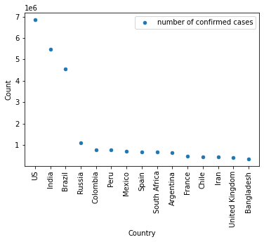

```python
Top15CountriesConfirmed.plot(kind = 'scatter', x = 'Country', y ="Count",label=("number of confirmed cases"))
plt.xticks(rotation = 90)
plt.legend()
plt.show()
```

*the inference about this plot is that US has the highest number of confimed covid cases around 6900000 and bangladesh has the lowest cases around 300000.Our country India is in the second position.*

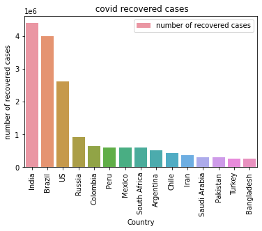

```python
import matplotlib.pyplot as plt
sns.barplot(Top15CountriesRecovered['Country'],Top15CountriesRecovered['Count'],label=("number of recovered cases"))
plt.title(" covid recovered cases")
plt.xlabel("Country")
plt.ylabel("number of recovered cases")
plt.xticks(rotation = 90)
plt.legend()
plt.show()
```

*the inference is India has the highest number of recovered covid cases and bangladesh has the lowest number of recovered cases.*

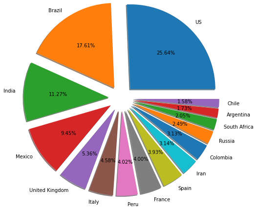

```python
explode=[0.3,0.3,0.3,0.3,0.3,0.3,0.3,0.3,0.3,0.3,0.3,0.3,0.3,0.3,0.3]
plt.pie(Top15CountriesDeaths["Count"],labels=Top15CountriesDeaths["Country"],autopct = "%0.2f%%",shadow = True,radius = 2,explode=explode)
plt.show()
```

*here US has the highest number of death covid cases(25.64%) and Chile has the lowest number of death cases(1.58).India is in the third position(11.27).*

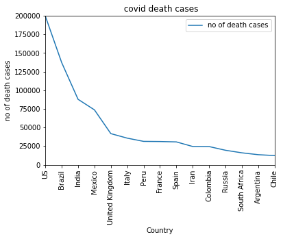

```python
import matplotlib.pyplot as plt
sns.lineplot(Top15CountriesDeaths['Country'],Top15CountriesDeaths['Count'],label=("no of death cases"))
#Top10CountriesDeath["Count"].plot()
plt.xlim(0,14)
plt.ylim(0,200000)
plt.title(" covid death cases")
plt.xlabel("Country")
plt.ylabel("no of death cases")
plt.xticks(rotation = 90)
plt.legend()
plt.show()
```

```python
def horizontal_bar_chart(Top15CountriesDeaths, x, y, title, x_label, y_label, color):
    fig = px.bar(Top15CountriesDeaths, x=x, y=y, orientation='h', title=title,
                 labels={x.name: x_label,
                         y.name: y_label}, color_discrete_sequence=[color])
    fig.update_layout(yaxis={'categoryorder': 'total ascending'})
    fig.show()
```

```python
Top15= Top15CountriesDeaths.sort_values(by='Count',ascending = False)
```

```python
Top15
```

|  | Country | Count |
| --- | --- | --- |
| 0 | US | 199865 |
| 1 | Brazil | 137272 |
| 2 | India | 87882 |
| 3 | Mexico | 73697 |
| 4 | United Kingdom | 41788 |
| 5 | Italy | 35724 |
| 6 | Peru | 31369 |
| 7 | France | 31174 |
| 8 | Spain | 30663 |
| 9 | Iran | 24478 |
| 10 | Colombia | 24397 |
| 11 | Russia | 19420 |
| 12 | South Africa | 15992 |
| 13 | Argentina | 13482 |
| 14 | Chile | 12298 |

```python
horizontal_bar_chart(Top15CountriesDeaths,Top15CountriesDeaths.Count, Top15CountriesDeaths.Country,
                     'Top 15 Countries with most deaths','Number of deaths(In Thousands)','country Name','Orange')
```

[interactive chart not shown]

```python
data.tail()
```

| Date | Province | Country | Lat | Long | Status | Count |
| --- | --- | --- | --- | --- | --- | --- |
| 2020-09-21 | NaN | West Bank and Gaza | 31.952200 | 35.233200 | Recovered | 24428 |
| 2020-09-21 | NaN | Western Sahara | 24.215500 | -12.885800 | Recovered | 8 |
| 2020-09-21 | NaN | Yemen | 15.552727 | 48.516388 | Recovered | 1235 |
| 2020-09-21 | NaN | Zambia | -13.133897 | 27.849332 | Recovered | 13629 |
| 2020-09-21 | NaN | Zimbabwe | -19.015438 | 29.154857 | Recovered | 5924 |

```python
data.info()
```

```
<class 'pandas.core.frame.DataFrame'>
DatetimeIndex: 191540 entries, 2020-01-22 to 2020-09-21
Data columns (total 6 columns):
 #   Column    Non-Null Count   Dtype
---  ------    --------------   -----
 0   Province  55876 non-null   object
 1   Country   191540 non-null  object
 2   Lat       191540 non-null  float64
 3   Long      191540 non-null  float64
 4   Status    191540 non-null  object
 5   Count     191540 non-null  int64
dtypes: float64(2), int64(1), object(3)
memory usage: 10.2+ MB
```

**Here we are using pivot for transforming the single rows into columns**

```python
import numpy as np
tranformeddata = pd.pivot_table(
            data,
            index = [data.index,'Province','Country','Lat','Long'],
            columns = 'Status',
            values = 'Count',
            )
```

```python
tranformeddata['Recovered'] = tranformeddata['Recovered'].fillna(0)
tranformeddata['Confirmed'] = tranformeddata['Confirmed'].fillna(0)
tranformeddata['Death'] = tranformeddata['Death'].fillna(0)
```

```python
tranformeddata = tranformeddata.reset_index()
tranformeddata.head()
```

| Status | Date | Province | Country | Lat | Long | Confirmed | Death | Recovered |
| --- | --- | --- | --- | --- | --- | --- | --- | --- |
| 0 | 2020-01-22 | Alberta | Canada | 53.9333 | -116.5765 | 0.0 | 0.0 | 0.0 |
| 1 | 2020-01-22 | Anguilla | United Kingdom | 18.2206 | -63.0686 | 0.0 | 0.0 | 0.0 |
| 2 | 2020-01-22 | Anhui | China | 31.8257 | 117.2264 | 1.0 | 0.0 | 0.0 |
| 3 | 2020-01-22 | Aruba | Netherlands | 12.5211 | -69.9683 | 0.0 | 0.0 | 0.0 |
| 4 | 2020-01-22 | Australian Capital Territory | Australia | -35.4735 | 149.0124 | 0.0 | 0.0 | 0.0 |

```python
tranformeddata.info()
```

```
<class 'pandas.core.frame.DataFrame'>
RangeIndex: 20252 entries, 0 to 20251
Data columns (total 8 columns):
 #   Column     Non-Null Count  Dtype
---  ------     --------------  -----
 0   Date       20252 non-null  datetime64[ns]
 1   Province   20252 non-null  object
 2   Country    20252 non-null  object
 3   Lat        20252 non-null  float64
 4   Long       20252 non-null  float64
 5   Confirmed  20252 non-null  float64
 6   Death      20252 non-null  float64
 7   Recovered  20252 non-null  float64
dtypes: datetime64[ns](1), float64(5), object(2)
memory usage: 1.2+ MB
```

```python
tranformeddata[tranformeddata['Country'] == 'India']
```

| Status | Date | Province | Country | Lat | Long | Confirmed | Death | Recovered |
| --- | --- | --- | --- | --- | --- | --- | --- | --- |

```python
Confirmed = tranformeddata.groupby("Date").sum()['Confirmed'].reset_index()
Death = tranformeddata.groupby("Date").sum()['Death'].reset_index()
Recovered = tranformeddata.groupby("Date").sum()['Recovered'].reset_index()
```

```python
Confirmed
```

|  | Date | Confirmed |
| --- | --- | --- |
| 0 | 2020-01-22 | 548.0 |
| 1 | 2020-01-23 | 643.0 |
| 2 | 2020-01-24 | 920.0 |
| 3 | 2020-01-25 | 1406.0 |
| 4 | 2020-01-26 | 2080.0 |
| ... | ... | ... |
| 239 | 2020-09-17 | 289439.0 |
| 240 | 2020-09-18 | 290914.0 |
| 241 | 2020-09-19 | 291734.0 |
| 242 | 2020-09-20 | 293041.0 |
| 243 | 2020-09-21 | 295227.0 |

244 rows × 2 columns

```python
Recovered
```

|  | Date | Recovered |
| --- | --- | --- |
| 0 | 2020-01-22 | 28.0 |
| 1 | 2020-01-23 | 30.0 |
| 2 | 2020-01-24 | 36.0 |
| 3 | 2020-01-25 | 39.0 |
| 4 | 2020-01-26 | 49.0 |
| ... | ... | ... |
| 239 | 2020-09-17 | 129855.0 |
| 240 | 2020-09-18 | 130535.0 |
| 241 | 2020-09-19 | 131569.0 |
| 242 | 2020-09-20 | 131797.0 |
| 243 | 2020-09-21 | 132095.0 |

244 rows × 2 columns

```python
Death
```

|  | Date | Death |
| --- | --- | --- |
| 0 | 2020-01-22 | 17.0 |
| 1 | 2020-01-23 | 18.0 |
| 2 | 2020-01-24 | 26.0 |
| 3 | 2020-01-25 | 42.0 |
| 4 | 2020-01-26 | 56.0 |
| ... | ... | ... |
| 239 | 2020-09-17 | 15127.0 |
| 240 | 2020-09-18 | 15143.0 |
| 241 | 2020-09-19 | 15154.0 |
| 242 | 2020-09-20 | 15161.0 |
| 243 | 2020-09-21 | 15177.0 |

244 rows × 2 columns

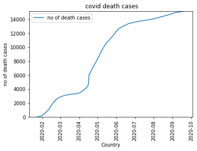

```python
sns.lineplot(Death['Date'],Death['Death'],label=("no of death cases"))
#Top10CountriesDeath["Count"].plot()

plt.ylim(0,15177)
plt.title(" covid death cases")
plt.xlabel("Country")
plt.ylabel("no of death cases")
plt.xticks(rotation = 90)
plt.legend()
plt.show()
```

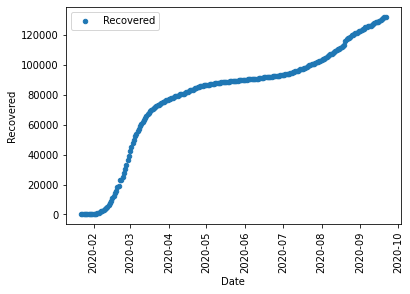

```python
Recovered.plot(kind = 'scatter', x = 'Date', y ="Recovered",label=("Recovered"))
plt.xticks(rotation = 90)
plt.legend()
plt.show()
```

*the recovered case is firstly less and then it is increased day by day*

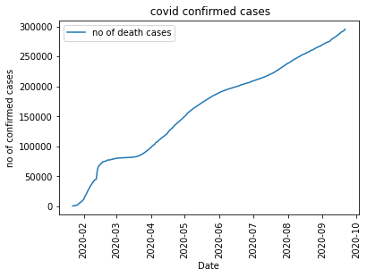

```python
sns.lineplot(Confirmed['Date'],Confirmed['Confirmed'],label=("no of death cases"))
plt.title(" covid confirmed cases")
plt.xlabel("Date")
plt.ylabel("no of confirmed cases")
plt.xticks(rotation = 90)
plt.legend()
plt.show()
```

**Time Series Forecasting using FB Prophet:**

*It is a procedure for forecasting time series data based on an additive model where non-linear trends are fit with yearly, weekly, and daily seasonality. It works with time series data that have strong seasonal effects and several seasons of historical data*

```python
import warnings
warnings.filterwarnings("ignore")
```

```python
from fbprophet import Prophet
```

```python
Confirmed = tranformeddata.groupby("Date").sum()['Confirmed'].reset_index()
Death = tranformeddata.groupby("Date").sum()['Death'].reset_index()
Recovered = tranformeddata.groupby("Date").sum()['Recovered'].reset_index()
```

```python
Confirmed
```

|  | Date | Confirmed |
| --- | --- | --- |
| 0 | 2020-01-22 | 548.0 |
| 1 | 2020-01-23 | 643.0 |
| 2 | 2020-01-24 | 920.0 |
| 3 | 2020-01-25 | 1406.0 |
| 4 | 2020-01-26 | 2080.0 |
| ... | ... | ... |
| 239 | 2020-09-17 | 289439.0 |
| 240 | 2020-09-18 | 290914.0 |
| 241 | 2020-09-19 | 291734.0 |
| 242 | 2020-09-20 | 293041.0 |
| 243 | 2020-09-21 | 295227.0 |

244 rows × 2 columns

*Changing column names as ds and y.ds is the date and y is the count*

```python
Confirmed.columns = ["ds", "y"]
Confirmed["ds"] = pd.to_datetime(Confirmed["ds"])
```

```python
Confirmed.tail()
```

|  | ds | y |
| --- | --- | --- |
| 239 | 2020-09-17 | 289439.0 |
| 240 | 2020-09-18 | 290914.0 |
| 241 | 2020-09-19 | 291734.0 |
| 242 | 2020-09-20 | 293041.0 |
| 243 | 2020-09-21 | 295227.0 |

**creating future dates of 100 days**

```python
model = Prophet()
model.fit(Confirmed)
future = model.make_future_dataframe(periods=100)
future.tail()
# it is taking weekly seasonality
```

```
INFO:fbprophet:Disabling yearly seasonality. Run prophet with yearly_seasonality=True to override this.
INFO:fbprophet:Disabling daily seasonality. Run prophet with daily_seasonality=True to override this.
```

|  | ds |
| --- | --- |
| 339 | 2020-12-26 |
| 340 | 2020-12-27 |
| 341 | 2020-12-28 |
| 342 | 2020-12-29 |
| 343 | 2020-12-30 |

```python
forecast = model.predict(future)
```

```python
forecast.head()
```

|  | ds | trend | yhat_lower | yhat_upper | trend_lower | trend_upper | additive_terms | additive_terms_lower | additive_terms_upper | weekly | weekly_lower | weekly_upper | multiplicative_terms | multiplicative_terms_lower | multiplicative_terms_upper | yhat |
| --- | --- | --- | --- | --- | --- | --- | --- | --- | --- | --- | --- | --- | --- | --- | --- | --- |
| 0 | 2020-01-22 | -1948.862978 | -3684.858012 | -642.331789 | -1948.862978 | -1948.862978 | -169.455505 | -169.455505 | -169.455505 | -169.455505 | -169.455505 | -169.455505 | 0.0 | 0.0 | 0.0 | -2118.318483 |
| 1 | 2020-01-23 | -748.658409 | -2023.853880 | 910.617231 | -748.658409 | -748.658409 | 169.427699 | 169.427699 | 169.427699 | 169.427699 | 169.427699 | 169.427699 | 0.0 | 0.0 | 0.0 | -579.230710 |
| 2 | 2020-01-24 | 451.546160 | -887.704211 | 2149.077943 | 451.546160 | 451.546160 | 194.227724 | 194.227724 | 194.227724 | 194.227724 | 194.227724 | 194.227724 | 0.0 | 0.0 | 0.0 | 645.773883 |
| 3 | 2020-01-25 | 1651.750728 | 158.077562 | 3213.159640 | 1651.750728 | 1651.750728 | 17.834907 | 17.834907 | 17.834907 | 17.834907 | 17.834907 | 17.834907 | 0.0 | 0.0 | 0.0 | 1669.585635 |
| 4 | 2020-01-26 | 2851.955297 | 1244.510086 | 4340.390282 | 2851.955297 | 2851.955297 | -60.916358 | -60.916358 | -60.916358 | -60.916358 | -60.916358 | -60.916358 | 0.0 | 0.0 | 0.0 | 2791.038939 |

```python
forecast[["ds","yhat","yhat_lower", "yhat_upper"]].tail()
```

|  | ds | yhat | yhat_lower | yhat_upper |
| --- | --- | --- | --- | --- |
| 339 | 2020-12-26 | 393793.831293 | 275171.701632 | 505826.598538 |
| 340 | 2020-12-27 | 394774.526047 | 273795.017447 | 510630.293328 |
| 341 | 2020-12-28 | 395855.631584 | 272846.048674 | 513955.495395 |
| 342 | 2020-12-29 | 396842.472815 | 271142.291336 | 516782.761377 |
| 343 | 2020-12-30 | 397844.324955 | 269809.427609 | 521176.629570 |

*plotting the predicted projection*

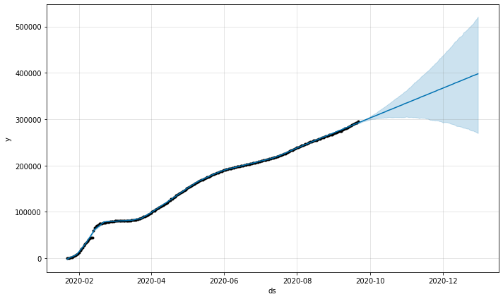

```python
Confirmed_forecast_plot = model.plot(forecast)
```

*The inference is the dotted points are actual data and the line is predicted data and the upper line is the trend.* *based on the trend confirmed cases increases.*

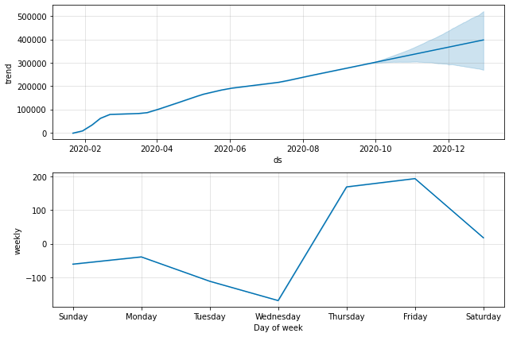

```python
confirmed_forecast_plot = model.plot_components(forecast)
```

```python
from fbprophet.diagnostics import cross_validation
confirmeddata = cross_validation(model, initial='130days', period='22days', horizon = '44days')
confirmeddata.head()
```

```
INFO:fbprophet:Making 4 forecasts with cutoffs between 2020-06-03 00:00:00 and 2020-08-08 00:00:00
```

|  | ds | yhat | yhat_lower | yhat_upper | y | cutoff |
| --- | --- | --- | --- | --- | --- | --- |
| 0 | 2020-06-04 | 194615.587105 | 193048.718890 | 196200.992426 | 192094.0 | 2020-06-03 |
| 1 | 2020-06-05 | 195781.507948 | 194178.454807 | 197486.686920 | 192847.0 | 2020-06-03 |
| 2 | 2020-06-06 | 196740.555088 | 195122.414240 | 198432.286724 | 193444.0 | 2020-06-03 |
| 3 | 2020-06-07 | 197872.936630 | 195946.880954 | 199886.743115 | 194209.0 | 2020-06-03 |
| 4 | 2020-06-08 | 198920.692445 | 196841.368861 | 201143.851821 | 194937.0 | 2020-06-03 |

```python
from fbprophet.diagnostics import performance_metrics
confirmeddata_p = performance_metrics(confirmeddata)
confirmeddata_p.head()
```

|  | horizon | mse | rmse | mae | mape | mdape | coverage |
| --- | --- | --- | --- | --- | --- | --- | --- |
| 0 | 5 days | 7.241878e+06 | 2691.073748 | 2556.338872 | 0.011798 | 0.011664 | 0.205882 |
| 1 | 6 days | 8.694648e+06 | 2948.668832 | 2790.536073 | 0.012851 | 0.012104 | 0.191176 |
| 2 | 7 days | 1.044883e+07 | 3232.465299 | 3045.886423 | 0.013996 | 0.012650 | 0.235294 |
| 3 | 8 days | 1.305818e+07 | 3613.610882 | 3365.549763 | 0.015472 | 0.012172 | 0.250000 |
| 4 | 9 days | 1.592138e+07 | 3990.160250 | 3674.214723 | 0.016902 | 0.012172 | 0.308824 |

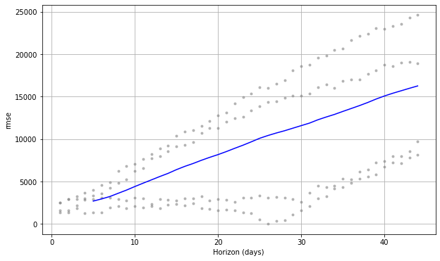

```python
from fbprophet.plot import plot_cross_validation_metric
fig = plot_cross_validation_metric(confirmeddata, metric='rmse')
```

```python
Recovered.columns = ["ds", "y"]
Recovered["ds"] = pd.to_datetime(Recovered["ds"])
```

```python
Recovered
```

|  | ds | y |
| --- | --- | --- |
| 0 | 2020-01-22 | 28.0 |
| 1 | 2020-01-23 | 30.0 |
| 2 | 2020-01-24 | 36.0 |
| 3 | 2020-01-25 | 39.0 |
| 4 | 2020-01-26 | 49.0 |
| ... | ... | ... |
| 239 | 2020-09-17 | 129855.0 |
| 240 | 2020-09-18 | 130535.0 |
| 241 | 2020-09-19 | 131569.0 |
| 242 | 2020-09-20 | 131797.0 |
| 243 | 2020-09-21 | 132095.0 |

244 rows × 2 columns

```python
Recovered.tail()
```

|  | ds | y |
| --- | --- | --- |
| 239 | 2020-09-17 | 129855.0 |
| 240 | 2020-09-18 | 130535.0 |
| 241 | 2020-09-19 | 131569.0 |
| 242 | 2020-09-20 | 131797.0 |
| 243 | 2020-09-21 | 132095.0 |

**creating future dates for 100 days**

```python
model = Prophet()
model.fit(Recovered)
future = model.make_future_dataframe(periods=100)
future.tail()
```

```
INFO:fbprophet:Disabling yearly seasonality. Run prophet with yearly_seasonality=True to override this.
INFO:fbprophet:Disabling daily seasonality. Run prophet with daily_seasonality=True to override this.
```

|  | ds |
| --- | --- |
| 339 | 2020-12-26 |
| 340 | 2020-12-27 |
| 341 | 2020-12-28 |
| 342 | 2020-12-29 |
| 343 | 2020-12-30 |

*taking tail() means selecting the last 5 rows*

```python
forecast = model.predict(future)
forecast[["ds","yhat","yhat_lower", "yhat_upper"]].tail()
```

|  | ds | yhat | yhat_lower | yhat_upper |
| --- | --- | --- | --- | --- |
| 339 | 2020-12-26 | 190249.487871 | 124684.365495 | 249233.574804 |
| 340 | 2020-12-27 | 190669.428396 | 123942.232858 | 250825.501598 |
| 341 | 2020-12-28 | 191181.476700 | 122862.449424 | 252644.499941 |
| 342 | 2020-12-29 | 191820.548870 | 122262.799171 | 253469.094609 |
| 343 | 2020-12-30 | 192438.112169 | 122659.543579 | 255627.753313 |

**plotting predicted projection**

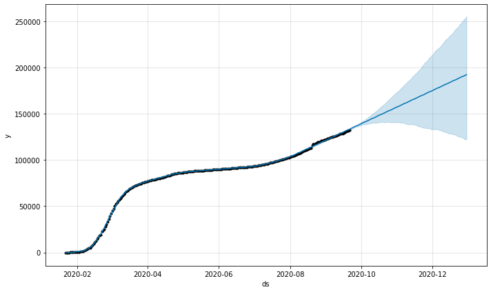

```python
recovered_forecast_plot = model.plot(forecast)
```

*The inference is the dotted points are actual data and the line is predicted data and the upper line is the trend. based on the trend recovered cases increases*

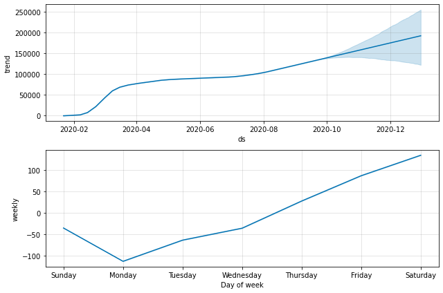

```python
Recovered_forecast_plot = model.plot_components(forecast)
```

```python
from fbprophet.diagnostics import cross_validation
recovereddata = cross_validation(model, initial='130days', period='22days', horizon = '44days')
recovereddata.head()
```

```
INFO:fbprophet:Making 4 forecasts with cutoffs between 2020-06-03 00:00:00 and 2020-08-08 00:00:00
```

|  | ds | yhat | yhat_lower | yhat_upper | y | cutoff |
| --- | --- | --- | --- | --- | --- | --- |
| 0 | 2020-06-04 | 90349.581548 | 90094.588582 | 90594.438016 | 90281.0 | 2020-06-03 |
| 1 | 2020-06-05 | 90466.819692 | 90164.224173 | 90763.602582 | 90332.0 | 2020-06-03 |
| 2 | 2020-06-06 | 90668.765642 | 90289.164778 | 91060.884069 | 90380.0 | 2020-06-03 |
| 3 | 2020-06-07 | 90676.643773 | 90151.678916 | 91231.530590 | 90438.0 | 2020-06-03 |
| 4 | 2020-06-08 | 90708.002482 | 89974.352176 | 91548.286855 | 90663.0 | 2020-06-03 |

```python
from fbprophet.diagnostics import performance_metrics
recovereddata_p = performance_metrics(recovereddata)
recovereddata_p.head()
```

|  | horizon | mse | rmse | mae | mape | mdape | coverage |
| --- | --- | --- | --- | --- | --- | --- | --- |
| 0 | 5 days | 1.919326e+06 | 1385.397566 | 1026.695519 | 0.009982 | 0.003195 | 0.5 |
| 1 | 6 days | 2.566199e+06 | 1601.936045 | 1195.169084 | 0.011560 | 0.014723 | 0.5 |
| 2 | 7 days | 3.136753e+06 | 1771.088088 | 1337.122462 | 0.012880 | 0.003983 | 0.5 |
| 3 | 8 days | 3.754950e+06 | 1937.769247 | 1482.099308 | 0.014232 | 0.006736 | 0.5 |
| 4 | 9 days | 4.374159e+06 | 2091.449035 | 1613.160376 | 0.015438 | 0.006806 | 0.5 |

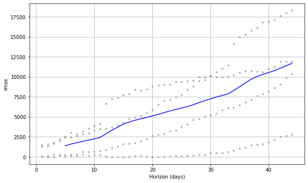

```python
from fbprophet.plot import plot_cross_validation_metric
fig = plot_cross_validation_metric(recovereddata, metric='rmse')
```

```python
Death.columns = ["ds", "y"]
Death["ds"] = pd.to_datetime(Death["ds"])
```

```python
Death.tail()
```

|  | ds | y |
| --- | --- | --- |
| 239 | 2020-09-17 | 15127.0 |
| 240 | 2020-09-18 | 15143.0 |
| 241 | 2020-09-19 | 15154.0 |
| 242 | 2020-09-20 | 15161.0 |
| 243 | 2020-09-21 | 15177.0 |

```python
model = Prophet()
model.fit(Death)
future = model.make_future_dataframe(periods=100)
future.tail()
```

```
INFO:fbprophet:Disabling yearly seasonality. Run prophet with yearly_seasonality=True to override this.
INFO:fbprophet:Disabling daily seasonality. Run prophet with daily_seasonality=True to override this.
```

|  | ds |
| --- | --- |
| 339 | 2020-12-26 |
| 340 | 2020-12-27 |
| 341 | 2020-12-28 |
| 342 | 2020-12-29 |
| 343 | 2020-12-30 |

```python
forecast = model.predict(future)
forecast[["ds","yhat","yhat_lower", "yhat_upper"]].tail()
```

|  | ds | yhat | yhat_lower | yhat_upper |
| --- | --- | --- | --- | --- |
| 339 | 2020-12-26 | 17435.206348 | 10407.208200 | 24510.512136 |
| 340 | 2020-12-27 | 17444.254148 | 10292.794556 | 24594.982090 |
| 341 | 2020-12-28 | 17459.610555 | 10206.117388 | 24676.619112 |
| 342 | 2020-12-29 | 17481.948206 | 10235.918393 | 24864.441013 |
| 343 | 2020-12-30 | 17504.961648 | 10177.883154 | 25000.772346 |

*plotting predicted projection*

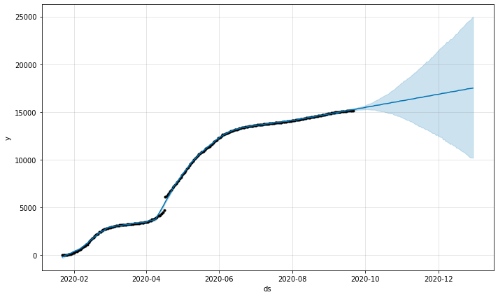

```python
Death_forecast_plot = model.plot(forecast)
```

*The inference is the dotted points are actual data and the line is predicted data and the upper line is the trend. based on the trend death cases increases*

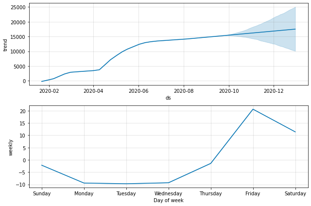

```python
Death_forecast_plot = model.plot_components(forecast)
```

```python
from fbprophet.diagnostics import cross_validation
deathdata = cross_validation(model, initial='130days', period='22days', horizon = '44days')
deathdata.head()
```

```
INFO:fbprophet:Making 4 forecasts with cutoffs between 2020-06-03 00:00:00 and 2020-08-08 00:00:00
```

|  | ds | yhat | yhat_lower | yhat_upper | y | cutoff |
| --- | --- | --- | --- | --- | --- | --- |
| 0 | 2020-06-04 | 12690.276174 | 12511.235154 | 12859.100916 | 12617.0 | 2020-06-03 |
| 1 | 2020-06-05 | 12854.060718 | 12689.646387 | 13025.721425 | 12678.0 | 2020-06-03 |
| 2 | 2020-06-06 | 12959.620324 | 12790.466847 | 13114.637986 | 12750.0 | 2020-06-03 |
| 3 | 2020-06-07 | 13061.764770 | 12891.101424 | 13245.320401 | 12777.0 | 2020-06-03 |
| 4 | 2020-06-08 | 13162.074243 | 12979.598291 | 13355.409382 | 12811.0 | 2020-06-03 |

```python
from fbprophet.diagnostics import performance_metrics
deathdata_p = performance_metrics(deathdata)
deathdata_p.head()
```

|  | horizon | mse | rmse | mae | mape | mdape | coverage |
| --- | --- | --- | --- | --- | --- | --- | --- |
| 0 | 5 days | 79662.537899 | 282.245528 | 230.671644 | 0.017179 | 0.013887 | 0.514706 |
| 1 | 6 days | 94824.253410 | 307.935470 | 254.722821 | 0.018969 | 0.010920 | 0.500000 |
| 2 | 7 days | 113017.583277 | 336.180879 | 281.415126 | 0.020929 | 0.016441 | 0.441176 |
| 3 | 8 days | 141403.014135 | 376.035921 | 314.969734 | 0.023388 | 0.027404 | 0.441176 |
| 4 | 9 days | 176850.598449 | 420.536085 | 350.926094 | 0.026024 | 0.030298 | 0.441176 |

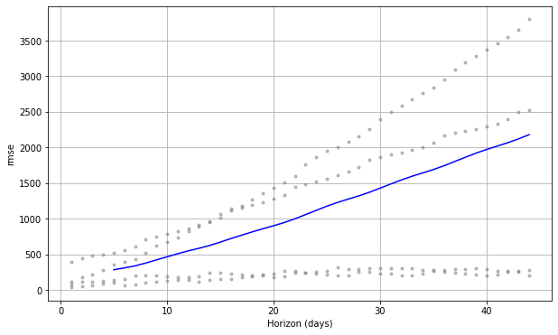

```python
from fbprophet.plot import plot_cross_validation_metric
fig = plot_cross_validation_metric(deathdata, metric='rmse')
```